# Project 1

Nathan Preuss

2020-09-28

Abstract

This project analyzes the software defects data table. 4 different algorithms were proposed to automate the process of finding a defect, and the efficacy of those algorithms is analyzed in this paper. 4 differenet measures for evaluating the algorithms were used, Accuracy, Detection Rate, False Alarm Rate, and Precision

# 1 Introduction to the data

## 1.1 About the Data Set

The data is a collection of programming modules for NASA Spacecraft Instruments. This code was evaluated line by line for defects, and returned true if the module had defective code, and false otherwise. Because collecting this data by hand was time consuming, several methods of predicting the existence of a defect were applied. We wish to see how accurate those methods of predicting defects are.

## 1.2 Summary Table

Summary Table for Evaluating Defect Prediction Algorithms:

|  |  | Module Has Defects |  |
| --- | --- | --- | --- |
|  |  | False | True |
| Algorithm Predicts Defects | No | a | b |
|  | Yes | c | d |

Latex formula for various evaluating techniques using a,b,c,d as shown above.

$$\begin{eqnarray}
Accuracy: P(Algorithm Is Correct) = \frac{a+d}{a+b+c+d}\\
Detection Rate: P(Predict Defect | Module Has Defect) = \frac{d}{b+d}\\
FalseAlarmRate: P(Predict Defect | Module Has No Defect) = \frac{c}{a+c}\\
Precision: P(Module Has Defect | Predict Defect) = \frac{d}{c+d}\\
\end{eqnarray}$$

# 2 R functions

```r
acc=function(a,b,c,d)
{
  return ((a+d)/(a+b+c+d))
}
```

```r
detect=function(b,d)
{
  return ((b)/(b+d))
}
```

```r
falarm=function(a,c)
{
  return ((c)/(a+c))
}
```

```r
prec=function(c,d)
{
  return ((d)/(c+d))
}
```

# 3 Creating Tables for the 4 different algorithms

```r
swd=read.csv("SWDEFECTS.csv")
head(swd)
```

|  | Mloc | Mvg | Mevg | Mivg | Hn | Hvol | Hpgmlen | Hdiff | Hintell | Heffort | Hb | Htime | Hloc | Hcomm | Hblank | loc.comm | uniOp | uniOpnd | totOp | totOpnd | brnchcnt | defect | predict.vg.10 | predict.evg.14.5 | predict.ivg.9.2 | predict.loc.50 |
| --- | --- | --- | --- | --- | --- | --- | --- | --- | --- | --- | --- | --- | --- | --- | --- | --- | --- | --- | --- | --- | --- | --- | --- | --- | --- | --- |
| 1 | 1.1 | 1.4 | 1.4 | 1.4 | 1.3 | 1.3 | 1.30 | 1.30 | 1.30 | 1 | 1.30 | 1 | 2 | 2 | 2 | 2 | 1.2 | 1.2 | 1.2 | 1.2 | 1.4 | FALSE | no | no | no | no |
| 2 | 1.0 | 1.0 | 1.0 | 1.0 | 1.0 | 1.0 | 1.00 | 1.00 | 1.00 | 1 | 1.00 | 1 | 1 | 1 | 1 | 1 | 1.0 | 1.0 | 1.0 | 1.0 | 1.0 | TRUE | no | no | no | no |
| 3 | 24.0 | 5.0 | 1.0 | 3.0 | 63.0 | 309.1 | 0.11 | 9.50 | 32.54 | 2937 | 0.10 | 163 | 1 | 0 | 6 | 0 | 15.0 | 15.0 | 44.0 | 19.0 | 9.0 | FALSE | no | no | no | no |
| 4 | 20.0 | 4.0 | 4.0 | 2.0 | 47.0 | 215.5 | 0.06 | 16.00 | 13.47 | 3448 | 0.07 | 192 | 0 | 0 | 3 | 0 | 16.0 | 8.0 | 31.0 | 16.0 | 7.0 | FALSE | no | no | no | no |
| 5 | 24.0 | 6.0 | 6.0 | 2.0 | 72.0 | 346.1 | 0.06 | 17.33 | 19.97 | 6000 | 0.12 | 333 | 0 | 0 | 3 | 0 | 16.0 | 12.0 | 46.0 | 26.0 | 11.0 | FALSE | no | no | no | no |
| 6 | 24.0 | 6.0 | 6.0 | 2.0 | 72.0 | 346.1 | 0.06 | 17.33 | 19.97 | 6000 | 0.12 | 333 | 0 | 0 | 3 | 0 | 16.0 | 12.0 | 46.0 | 26.0 | 11.0 | FALSE | no | no | no | no |

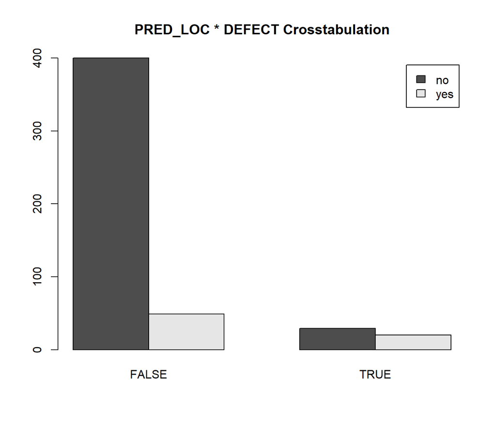

```r
tab=with(swd, table(predict.loc.50,defect))
barplot(tab, beside=TRUE, leg=TRUE, main="PRED_LOC * DEFECT Crosstabulation")
```

```r
tab2=addmargins(tab)
tab2
```

```
##               defect
## predict.loc.50 FALSE TRUE Sum
##            no    400   29 429
##            yes    49   20  69
##            Sum   449   49 498
```

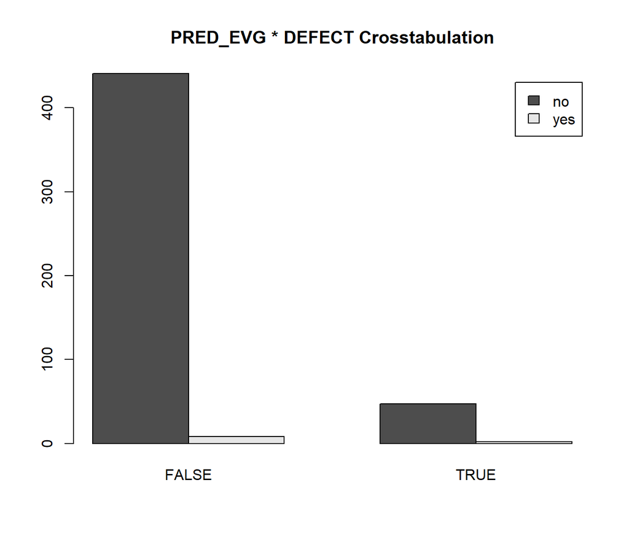

```r
tab=with(swd, table(predict.evg.14.5,defect))
barplot(tab, beside=TRUE, leg=TRUE, main="PRED_EVG * DEFECT Crosstabulation")
```

```r
tab2=addmargins(tab)
tab2
```

```
##                 defect
## predict.evg.14.5 FALSE TRUE Sum
##              no    441   47 488
##              yes     8    2  10
##              Sum   449   49 498
```

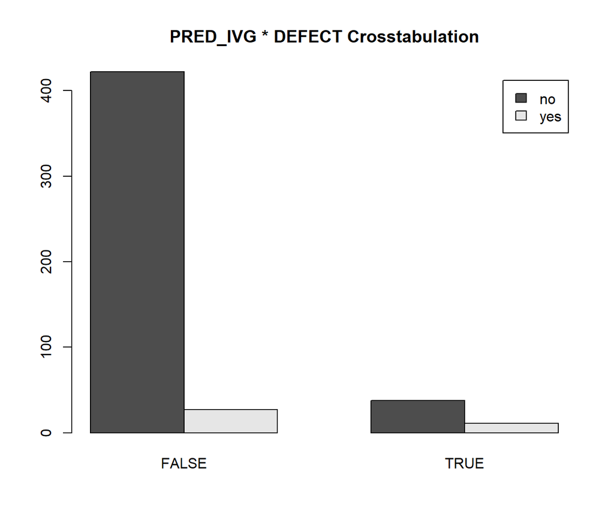

```r
tab=with(swd, table(predict.ivg.9.2,defect))
barplot(tab, beside=TRUE, leg=TRUE, main="PRED_IVG * DEFECT Crosstabulation")
```

```r
tab2=addmargins(tab)
tab2
```

```
##                defect
## predict.ivg.9.2 FALSE TRUE Sum
##             no    422   38 460
##             yes    27   11  38
##             Sum   449   49 498
```

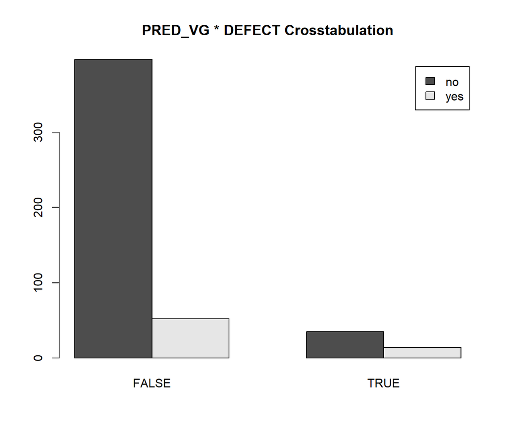

```r
tab=with(swd, table(predict.vg.10,defect))
barplot(tab, beside=TRUE, leg=TRUE, main="PRED_VG * DEFECT Crosstabulation")
```

```r
tab2=addmargins(tab)
tab2
```

```
##              defect
## predict.vg.10 FALSE TRUE Sum
##           no    397   35 432
##           yes    52   14  66
##           Sum   449   49 498
```